# Lab Aprendizaje No Supervisado

Pedro Avila, Javier Benitez, Brandon Rivera

2026-02-07

```r
# dependecies
#install.packages("dplyr")
```

# Librerias

```r
library(ggplot2)
library(dplyr)
library(nortest)
library(scales)
library(lubridate)
library(cluster)
library(factoextra)
library(arules)
library(arulesViz)
library(hopkins)
library(fpc)
library(psych)
library(corrplot)
library(tidyr)
```

# Exploracion de datos

- Una exploración rápida de sus datos, para eso haga un resumen de su conjunto de datos.

```r
movies <- read.csv("Movies_2026.csv", fileEncoding = "latin1")

str(movies)
```

```
## 'data.frame':    19883 obs. of  28 variables:
##  $ id                       : int  1627085 1626914 1626898 1626808 1626678 1626234 1626010 1625551 1625043 1624457 ...
##  $ budget                   : num  0 0 0 0 0 1 0 0 0 0 ...
##  $ genres                   : chr  "Drama|Crime" "Animation" "Animation" "Thriller|Mystery|Documentary" ...
##  $ homePage                 : chr  "" "" "" "" ...
##  $ productionCompany        : chr  "" "" "" "" ...
##  $ productionCompanyCountry : chr  "" "" "" "" ...
##  $ productionCountry        : chr  "" "" "" "" ...
##  $ revenue                  : num  0 0 0 0 0 1 0 0 0 0 ...
##  $ runtime                  : int  95 3 2 5 12 14 39 90 96 106 ...
##  $ video                    : logi  FALSE FALSE FALSE FALSE FALSE FALSE ...
##  $ director                 : chr  "Javad Hakami" "Kimmy Gatewood" "Kimmy Gatewood" "Felipe RoldÃ¡n" ...
##  $ actors                   : chr  "Mohsen Ghasabian|Aida Mahiani|Mehran Ghafourian|Payam Ahmadinia|Masoud Karamati|Roya Javidnia|Nasim Adabi|Siavash Cheraghipour" "Kameron Jackson|Laura Weaving|sara weaving|Bertha Williams" "Cedric Mitchell|Cajun mills|Laura Williams" "TomÃ¡s Tuchsznajder|Matias…
##  $ actorsPopularity         : chr  "0.3453|0.1664|0.9684|0.3437|0.3713|0.2437|0.2796|0.2639" "0|0.0071|0|0" "0.0193|0|0.0143" "0|0|0|0|0|0|0" ...
##  $ actorsCharacter          : chr  "|||||||" "Prince Charming|Evil Stepmother|Fairy Godmother|Cinderella" "Aladdin|Jafar|Jasmine" "||||||" ...
##  $ originalTitle            : chr  "ØºÙ\u0088Ø·Ù\u0087 Ù\u0088Ø±" "Cinderella" "Aladdin" "EL ANILLO Y EL DECK" ...
##  $ title                    : chr  "Immersed" "Cinderella" "Aladdin" "THE RING AND THE DECK" ...
##  $ originalLanguage         : chr  "fa" "en" "en" "es" ...
##  $ popularity               : num  0.0357 0.0357 0.0214 0.0429 0.0379 ...
##  $ releaseDate              : chr  "2026-02-01" "2026-02-01" "2026-02-01" "2026-02-01" ...
##  $ voteAvg                  : num  0 0 0 0 0 0 0 0 0 0 ...
##  $ voteCount                : int  0 0 0 0 0 0 0 0 0 0 ...
##  $ genresAmount             : int  2 1 1 3 1 1 1 1 3 1 ...
##  $ productionCoAmount       : int  0 0 0 0 0 0 0 0 0 0 ...
##  $ productionCountriesAmount: int  0 0 0 0 0 0 0 1 1 0 ...
##  $ actorsAmount             : int  8 4 3 7 3 3 5 4 5 5 ...
##  $ castWomenAmount          : int  2 0 0 0 0 0 0 3 1 2 ...
##  $ castMenAmount            : int  5 0 0 0 0 0 3 0 3 3 ...
##  $ releaseYear              : int  2026 2026 2026 2026 2026 2026 2026 2026 2026 2026 ...
```

- Al momento de usar `str()`, nos podemos hacer una idea de como son los datos en todo el dataset, este analisis se hace luego en el proyecto (en especifico en el inciso 2). Como nos podemos dar cuenta varios de estos campos llegan a tener informacion vacia para su tipo de dato respectivo.

```r
movies <- subset(movies, select = -id) # we ain't going to summarize the the id for pretty obvious reasons
summary(movies)
```

```
##      budget             genres            homePage         productionCompany
##  Min.   :        0   Length:19883       Length:19883       Length:19883
##  1st Qu.:        0   Class :character   Class :character   Class :character
##  Median :        0   Mode  :character   Mode  :character   Mode  :character
##  Mean   :  9413280
##  3rd Qu.:  1000000
##  Max.   :380000000
##
##  productionCompanyCountry productionCountry     revenue
##  Length:19883             Length:19883       Min.   :0.000e+00
##  Class :character         Class :character   1st Qu.:0.000e+00
##  Mode  :character         Mode  :character   Median :0.000e+00
##                                              Mean   :2.879e+07
##                                              3rd Qu.:3.306e+05
##                                              Max.   :2.847e+09
##
##     runtime         video           director            actors
##  Min.   :  0.00   Mode :logical   Length:19883       Length:19883
##  1st Qu.: 10.00   FALSE:19313     Class :character   Class :character
##  Median : 86.00   TRUE :84        Mode  :character   Mode  :character
##  Mean   : 66.09   NA's :486
##  3rd Qu.:103.00
##  Max.   :750.00
##
##  actorsPopularity   actorsCharacter    originalTitle         title
##  Length:19883       Length:19883       Length:19883       Length:19883
##  Class :character   Class :character   Class :character   Class :character
##  Mode  :character   Mode  :character   Mode  :character   Mode  :character
##
##
##
##
##  originalLanguage     popularity        releaseDate           voteAvg
##  Length:19883       Min.   :0.000e+00   Length:19883       Min.   : 0.000
##  Class :character   1st Qu.:5.460e-02   Class :character   1st Qu.: 0.000
##  Mode  :character   Median :8.502e+00   Mode  :character   Median : 5.400
##                     Mean   :2.625e+01                      Mean   : 3.837
##                     3rd Qu.:2.224e+01                      3rd Qu.: 6.800
##                     Max.   :1.147e+04                      Max.   :10.000
##
```

[output cut: 9 more lines]

```
##  Min.   :  0.00            Min.   :     0   Min.   :     0   Min.   :     0
##  1st Qu.:  1.00            1st Qu.:     3   1st Qu.:     0   1st Qu.:     0
##  Median :  1.00            Median :     9   Median :     2   Median :     3
##  Mean   :  1.23            Mean   :  1082   Mean   :  3517   Mean   :  8224
##  3rd Qu.:  1.00            3rd Qu.:    21   3rd Qu.:     6   3rd Qu.:    12
##  Max.   :155.00            Max.   :919590   Max.   :922162   Max.   :922017
##                                             NA's   :37       NA's   :162
##   releaseYear
##  Min.   :1902
##  1st Qu.:2013
##  Median :2021
##  Mean   :2017
##  3rd Qu.:2025
##  Max.   :2026
##  NA's   :2
```

- Al resumirlos no podemos agarrar informacion tan relevante para hacer cualquier tipo de analisis ademas de algunos valores numericos en dichos campos. Como ver cantidad de ingresos maximos y medios, prespuesto y ganancia por peliculas. No llega a ser informacion tan valiosa solo viendola de por si, ya que son datos generales entre todas y no de una solo empresa o por el estilo (se puede ‘queriear’ para lograrlo, pero ese no es el caso).

## Tipo de cada una de las variables

- (cualitativa ordinal o nominal, cuantitativa continua, cuantitativa discreta)

**Cualitativas** Adicionalmente en estas clasificaciones las variables Actors y ActorsCharacters serian clasificados como cualitativos nominales pero no se agregaron porque es necesario una limpieza de datos antes.

```r
cual_nominales <- c(
  "genres",
  "homePage",
  "productionCompany",
  "productionCompanyCountry",
  "productionCountry",
  "video",
  "director",
  "originalTitle",
  "title",
  "originalLanguage"
)

cual_ordinales <- c(
  "releaseDate"
)

cualitativas <- c(cual_nominales, cual_ordinales)
cualitativas
```

```
##  [1] "genres"                   "homePage"
##  [3] "productionCompany"        "productionCompanyCountry"
##  [5] "productionCountry"        "video"
##  [7] "director"                 "originalTitle"
##  [9] "title"                    "originalLanguage"
## [11] "releaseDate"
```

```r
datos_cual <- movies[, cualitativas]
head(datos_cual, 5)
```

|  | genres | homePage | productionCompany | productionCompanyCountry | productionCountry | video | director | originalTitle | title | originalLanguage | releaseDate |
| --- | --- | --- | --- | --- | --- | --- | --- | --- | --- | --- | --- |
| 1 | Drama\|Crime |  |  |  |  | FALSE | Javad Hakami | ØºÙ\u0088Ø·Ù\u0087 Ù\u0088Ø± | Immersed | fa | 2026-02-01 |
| 2 | Animation |  |  |  |  | FALSE | Kimmy Gatewood | Cinderella | Cinderella | en | 2026-02-01 |
| 3 | Animation |  |  |  |  | FALSE | Kimmy Gatewood | Aladdin | Aladdin | en | 2026-02-01 |
| 4 | Thriller\|Mystery\|Documentary |  |  |  |  | FALSE | Felipe RoldÃ¡n | EL ANILLO Y EL DECK | THE RING AND THE DECK | es | 2026-02-01 |
| 5 | Animation |  |  |  |  | FALSE | Kimmy Gatewood | Crimson High 3 | Crimson High 3 | en | 2026-02-01 |

**Cuantitativas** Adicionalmente en estas clasificaciones la variable ActorsPopularity serian clasificados como cuantitativos continuos pero no se agregaron porque es necesario una limpieza de datos antes.

```r
cuant_discretas <- c(
  "budget",
  "revenue",
  "runtime",
  "voteAvg",
  "voteCount",
  "genresAmount",
  "productionCoAmount",
  "productionCountriesAmount",
  "actorsAmount",
  "castWomenAmount",
  "castMenAmount",
  "releaseYear"
)

cuant_continuas <- c(
  "popularity"
)

cuantitativas <- c(cuant_discretas, cuant_continuas)
cuantitativas
```

```
##  [1] "budget"                    "revenue"
##  [3] "runtime"                   "voteAvg"
##  [5] "voteCount"                 "genresAmount"
##  [7] "productionCoAmount"        "productionCountriesAmount"
##  [9] "actorsAmount"              "castWomenAmount"
## [11] "castMenAmount"             "releaseYear"
## [13] "popularity"
```

```r
datos_cuant <- movies[, cuantitativas]
head(datos_cuant, 5)
```

|  | budget | revenue | runtime | voteAvg | voteCount | genresAmount | productionCoAmount | productionCountriesAmount | actorsAmount | castWomenAmount | castMenAmount | releaseYear | popularity |
| --- | --- | --- | --- | --- | --- | --- | --- | --- | --- | --- | --- | --- | --- |
| 1 | 0 | 0 | 95 | 0 | 0 | 2 | 0 | 0 | 8 | 2 | 5 | 2026 | 0.0357 |
| 2 | 0 | 0 | 3 | 0 | 0 | 1 | 0 | 0 | 4 | 0 | 0 | 2026 | 0.0357 |
| 3 | 0 | 0 | 2 | 0 | 0 | 1 | 0 | 0 | 3 | 0 | 0 | 2026 | 0.0214 |
| 4 | 0 | 0 | 5 | 0 | 0 | 3 | 0 | 0 | 7 | 0 | 0 | 2026 | 0.0429 |
| 5 | 0 | 0 | 12 | 0 | 0 | 1 | 0 | 0 | 3 | 0 | 0 | 2026 | 0.0379 |

# Análisis de Clustering

## Paso 0: Preparación de datos

Se seleccionan 6 variables numéricas: `budget`, `revenue`, `popularity`, `voteAvg`, `voteCount` y `runtime`. Se excluyen variables de texto, fechas y conteos auxiliares que no aportarían patrones útiles. Se eliminan registros con `budget = 0` y `revenue = 0` por ser datos incompletos. Tras la limpieza quedan 4,262 películas.

```r
# Variables numéricas seleccionadas para clustering
vars_cluster <- c("budget", "revenue", "popularity", "voteAvg", "voteCount", "runtime")

# Eliminar NAs, duplicados y películas sin datos comerciales
d2f_raw <- na.omit(movies[, c("title", vars_cluster)])
d2f_raw <- d2f_raw[!duplicated(d2f_raw$title), ]
d2f_raw <- d2f_raw[d2f_raw$budget > 0 & d2f_raw$revenue > 0, ]

# Escalar datos (necesario: las variables tienen magnitudes muy distintas)
d2f <- as.data.frame(scale(d2f_raw[, vars_cluster]))
rownames(d2f) <- d2f_raw$title

cat("Títulos duplicados:", sum(duplicated(rownames(d2f))), "\n")
```

```
## Títulos duplicados: 0
```

```r
cat("Filas totales para clustering:", nrow(d2f), "\n")
```

```
## Filas totales para clustering: 4262
```

## Paso 1: Tendencia al agrupamiento — Hopkins y VAT

### Estadístico de Hopkins

El estadístico de Hopkins mide la tendencia al agrupamiento natural. Valores cercanos a 1 indican alta tendencia; cercanos a 0.5 sugieren distribución aleatoria.

```r
set.seed(123)
muestra_hop <- d2f[sample(nrow(d2f), min(500, nrow(d2f))), ]
hop_resultado <- hopkins(muestra_hop, m = 50)
cat("Estadístico de Hopkins:", round(hop_resultado, 4), "\n")
```

```
## Estadístico de Hopkins: 1
```

El estadístico resultó muy cercano a 1.0, confirmando alta tendencia al agrupamiento natural. Aplicar clustering sobre estos datos es estadísticamente válido.

### VAT (Visual Assessment of Tendency)

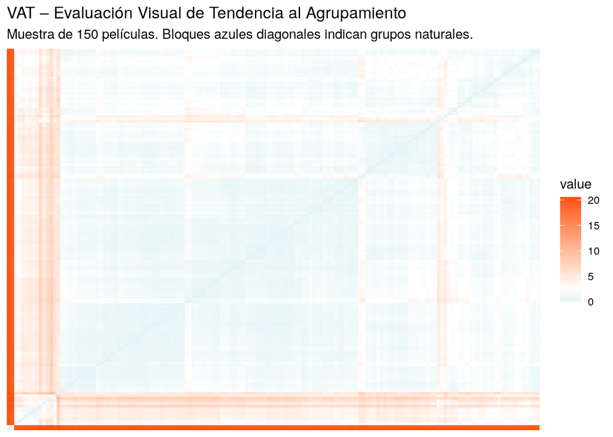

```r
set.seed(123)
n_vat <- min(150, nrow(d2f))
muestra_vat <- d2f[sample(nrow(d2f), n_vat), ]
dist_vat <- dist(muestra_vat, method = "euclidean")

fviz_dist(dist_vat, show_labels = FALSE,
          gradient = list(low = "#00AFBB", mid = "white", high = "#FC4E07")) +
  labs(title    = "VAT – Evaluación Visual de Tendencia al Agrupamiento",
       subtitle = paste("Muestra de", n_vat, "películas. Bloques azules diagonales indican grupos naturales."))
```

La gráfica muestra la matriz de distancias reordenada. Se distingue una zona azul central (la mayoría de películas con perfil comercial similar) y zonas naranjas en los bordes correspondientes a producciones con valores extremos en popularidad o ingresos. Esto confirma la presencia de grupos naturales, aunque con una distribución asimétrica donde la gran mayoría comparte características parecidas.

## Paso 2: Determinación del número óptimo de clusters

> Nota técnica: Se usa una muestra de 2,000 películas para los métodos de determinación de k, evitando el alto consumo de RAM que generaría calcular matrices de distancias O(n²) sobre el dataset completo.

```r
set.seed(123)
n_muestra <- min(2000, nrow(d2f))
idx_muestra <- sample(nrow(d2f), n_muestra)
d2f_muestra <- d2f[idx_muestra, ]
cat("Muestra utilizada para determinar k:", n_muestra, "películas\n")
```

```
## Muestra utilizada para determinar k: 2000 películas
```